# Part 9 Dimensionality Reduction

There are two ways for dimensionality Reduction: - Feature Selection: - Backward Elimination - Forward Elimination - Bidirectional Elimination - Score Comparison

- Feature Extraction:
  - PCA
  - LDA
  - Kernel PCA

## 9.1 Principle Component Analysis (PCA)

### 9.1.1 PCA Intuition

PCA is used to reduce the dimensions of a $d$-dimensional dataset by projecting it onto a ($k$)-dimensional subspace (where $k<d$). PCA extracts new independent variables explain the most the variance of the dataset. The fact that the DV is not considered makes PCA an unsupervised model. The goal of PCA is to: - Identify patterns in data - Detect the correlation between variables

The algorithm of PCA is: - **STEP 1**: Standardize the data. - **STEP 2**: Obtain the eigenvectors and eigenvalues from the covariance matrix or correlation matrix, or perform singular vector decomposition. - **STEP 3**: Sort eigenvalues in descending order and choose the $k$ eigenvectors that correspond to the $k$ largest eigenvalues where $k$ is the number of dimensions of the new feature subspace ($k\leq d$). - **STEP 4**: Construct the projection matrix $W$ from the selected $k$ eigenvectors. - **STEP 5**: Transform the original dataset $X$ via $W$ to obtain a $k$-dimensional feature subspace $Y$.

### 9.1.2 PCA in R

```r
# Importing the dataset
dataset = read.csv('Wine.csv')
head(dataset)
```

|  | Alcohol | Malic_Acid | Ash | Ash_Alcanity | Magnesium | Total_Phenols | Flavanoids | Nonflavanoid_Phenols | Proanthocyanins | Color_Intensity | Hue | OD280 | Proline | Customer_Segment |
| --- | --- | --- | --- | --- | --- | --- | --- | --- | --- | --- | --- | --- | --- | --- |
| 1 | 14.23 | 1.71 | 2.43 | 15.6 | 127 | 2.80 | 3.06 | 0.28 | 2.29 | 5.64 | 1.04 | 3.92 | 1065 | 1 |
| 2 | 13.20 | 1.78 | 2.14 | 11.2 | 100 | 2.65 | 2.76 | 0.26 | 1.28 | 4.38 | 1.05 | 3.40 | 1050 | 1 |
| 3 | 13.16 | 2.36 | 2.67 | 18.6 | 101 | 2.80 | 3.24 | 0.30 | 2.81 | 5.68 | 1.03 | 3.17 | 1185 | 1 |
| 4 | 14.37 | 1.95 | 2.50 | 16.8 | 113 | 3.85 | 3.49 | 0.24 | 2.18 | 7.80 | 0.86 | 3.45 | 1480 | 1 |
| 5 | 13.24 | 2.59 | 2.87 | 21.0 | 118 | 2.80 | 2.69 | 0.39 | 1.82 | 4.32 | 1.04 | 2.93 | 735 | 1 |
| 6 | 14.20 | 1.76 | 2.45 | 15.2 | 112 | 3.27 | 3.39 | 0.34 | 1.97 | 6.75 | 1.05 | 2.85 | 1450 | 1 |

```r
# Splitting the dataset into the training and test set
library(caTools)
set.seed(123)
split = sample.split(dataset$Customer_Segment, SplitRatio = 0.8)
training_set = subset(dataset, split == TRUE)
test_set = subset(dataset, split == FALSE)
```

```r
# Feature scaling
training_set[-14] = scale(training_set[-14])
test_set[-14] = scale(test_set[-14])
```

```r
# Apply PCA
library(caret)
pca = preProcess(x = training_set[-14],
                 method = 'pca',
                 pcaComp = 2)
training_set = predict(pca, training_set)
training_set = training_set[c(2, 3, 1)]
test_set = predict(pca, test_set)
test_set = test_set[c(2, 3, 1)]
```

```r
# Fitting svm to the training set
library(e1071)
classifier = svm(formula = Customer_Segment ~ .,
                 data = training_set,
                 type = 'C-classification',
                 kernel = 'linear')
```

```r
# Predicing the test set results
y_pred = predict(classifier, newdata = test_set[-3])
y_pred
```

```
  4   5   8  11  16  20  21  24  31  32  50  59  65  67  68  69  87  88  89 104 106 107
  1   1   1   1   1   1   1   1   1   1   1   1   2   2   2   2   2   2   2   2   2   2
111 114 118 126 132 134 137 138 139 145 151 167 173 174
  2   2   2   2   3   3   3   3   3   3   3   3   3   3
Levels: 1 2 3
```

```r
# Making the confusion matrix
cm = table(test_set[, 3], y_pred)
cm
```

```
   y_pred
     1  2  3
  1 12  0  0
  2  0 14  0
  3  0  0 10
```

```r
# Visualizing the training set results
library(ElemStatLearn)
set = training_set
X1 = seq(min(set[, 1]) - 1, max(set[, 1]) + 1, by = 0.01)
X2 = seq(min(set[, 2]) - 1, max(set[, 2]) + 1, by = 0.01)
grid_set = expand.grid(X1, X2)
colnames(grid_set) = c('PC1', 'PC2')
y_grid = predict(classifier, newdata = grid_set)
plot(set[, -3],
     main = 'SVM (Training Set with PCA)',
     xlab = 'PC1', ylab = 'PC2',
     xlim = range(X1), ylim = range(X2))
contour(X1, X2, matrix(as.numeric(y_grid), length(X1), length(X2)), add = TRUE)
```

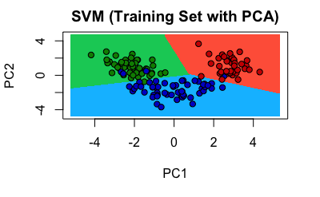

```r
points(grid_set, pch = '.', col = ifelse(y_grid == 2, 'deepskyblue', ifelse(y_grid == 1, 'springgreen3', 'tomato')))
points(set, pch = 21, bg = ifelse(set[, 3] == 2, 'blue3', ifelse(set[, 3] == 1, 'green4', 'red3')))
```

```r
# Visualizing the test set results
library(ElemStatLearn)
set = test_set
X1 = seq(min(set[, 1]) - 1, max(set[, 1]) + 1, by = 0.01)
X2 = seq(min(set[, 2]) - 1, max(set[, 2]) + 1, by = 0.01)
grid_set = expand.grid(X1, X2)
colnames(grid_set) = c('PC1', 'PC2')
y_grid = predict(classifier, newdata = grid_set)
plot(set[, -3],
     main = 'SVM (Test Set with PCA)',
     xlab = 'PC1', ylab = 'PC2',
     xlim = range(X1), ylim = range(X2))
contour(X1, X2, matrix(as.numeric(y_grid), length(X1), length(X2)), add = TRUE)
```

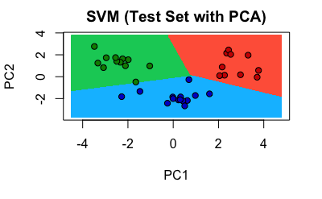

```r
points(grid_set, pch = '.', col = ifelse(y_grid == 2, 'deepskyblue', ifelse(y_grid == 1, 'springgreen3', 'tomato')))
points(set, pch = 21, bg = ifelse(set[, 3] == 2, 'blue3', ifelse(set[, 3] == 1, 'green4', 'red3')))
```

## 9.2 Linear Discriminant Analysis (LDA)

### 9.2.1 LDA Intuition

LDA is: - Used as a dimensionality reduction technique - Used in the pre-processing step for pattern classification - Has the goal to project a dataset onto a lower-dimensional space

It sounds similar to PCA. But LDA differs because in addition to finding the component axies with LDA we are interested in the axes that maximize the separation between multiple classes. The goal of LDA is to project a feature space (a dataset $n$-dimensional sample) onto a small subspace $k$ (where $k\leq n-1$) while maintaining the class-discriminatory information. Both PCA and LDA are linear transformation techniques used for dimensionality reduction. PCA is described as unsupervised but LDA is supervised because of the relation to the dependent variable.

The algorithm of LDA is: - **STEP 1**: Compute the $d$-dimensional mean vectors for the different classes from the dataset. - **STEP 2**: Compute the scatter matrices (in-between-class and within-class scatter matrix). - **STEP 3**: Compute the eigenvectors ($e_1,e_2,\dots,e_d$) and corresponding eigenvalues($\lambda_1,\lambda_2,\dots,\lambda_d$) for the scatter matrices. - **STEP 4**: Sort the eigenvectors by decreasing eigenvalues and choose $k$ eigenvectors with the largest eigenvalues to form a $d\times k$ dimensional matrix $W$ (where every column represents a eigenvector). - **STEP 5**: Use this $d\times k$ eigenvector matrix to transform the samples onto the new subspace. This can be summarized by the matrix multiplication: $Y=X\times W$ (where $X$ is a $n\times d$-dimensional matrix representing the $n$ samples, and $y$ are the transformed $n\times d$-dimensional samples in the new subspace).

### 9.2.2 LDA in R

```r
# Splitting the dataset into the training and test set
library(caTools)
set.seed(123)
split = sample.split(dataset$Customer_Segment, SplitRatio = 0.8)
training_set = subset(dataset, split == TRUE)
test_set = subset(dataset, split == FALSE)
```

```r
# Feature scaling
training_set[-14] = scale(training_set[-14])
test_set[-14] = scale(test_set[-14])
```

```r
# Applying LDA
library(MASS)
lda = lda(formula = Customer_Segment ~ ., data = training_set)
training_set = as.data.frame(predict(lda, training_set))
training_set = training_set[c(5, 6, 1)]
test_set = as.data.frame(predict(lda, test_set))
test_set = test_set[c(5, 6, 1)]
```

```r
# Fitting svm to the training set
library(e1071)
classifier = svm(formula = class ~ .,
                 data = training_set,
                 type = 'C-classification',
                 kernel = 'linear')
```

```r
# Predicing the test set results
y_pred = predict(classifier, newdata = test_set[-3])
y_pred
```

```
  4   5   8  11  16  20  21  24  31  32  50  59  65  67  68  69  87  88  89 104 106 107
  1   1   1   1   1   1   1   1   1   1   1   1   2   2   2   1   2   2   2   2   2   2
111 114 118 126 132 134 137 138 139 145 151 167 173 174
  2   2   2   2   3   3   3   3   3   3   3   3   3   3
Levels: 1 2 3
```

```r
# Making the confusion matrix
cm = table(test_set[, 3], y_pred)
cm
```

```
   y_pred
     1  2  3
  1 12  0  0
  2  1 13  0
  3  0  0 10
```

```r
# Visualizing the training set results
library(ElemStatLearn)
set = training_set
X1 = seq(min(set[, 1]) - 1, max(set[, 1]) + 1, by = 0.01)
X2 = seq(min(set[, 2]) - 1, max(set[, 2]) + 1, by = 0.01)
grid_set = expand.grid(X1, X2)
colnames(grid_set) = c('x.LD1', 'x.LD2')
y_grid = predict(classifier, newdata = grid_set)
plot(set[, -3],
     main = 'SVM (Training Set with LDA)',
     xlab = 'LD1', ylab = 'LD2',
     xlim = range(X1), ylim = range(X2))
contour(X1, X2, matrix(as.numeric(y_grid), length(X1), length(X2)), add = TRUE)
```

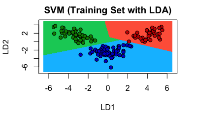

```r
points(grid_set, pch = '.', col = ifelse(y_grid == 2, 'deepskyblue', ifelse(y_grid == 1, 'springgreen3', 'tomato')))
points(set, pch = 21, bg = ifelse(set[, 3] == 2, 'blue3', ifelse(set[, 3] == 1, 'green4', 'red3')))
```

```r
# Visualizing the test set results
library(ElemStatLearn)
set = training_set
X1 = seq(min(set[, 1]) - 1, max(set[, 1]) + 1, by = 0.01)
X2 = seq(min(set[, 2]) - 1, max(set[, 2]) + 1, by = 0.01)
grid_set = expand.grid(X1, X2)
colnames(grid_set) = c('x.LD1', 'x.LD2')
y_grid = predict(classifier, newdata = grid_set)
plot(set[, -3],
     main = 'SVM (Test Set with LDA)',
     xlab = 'LD1', ylab = 'LD2',
     xlim = range(X1), ylim = range(X2))
contour(X1, X2, matrix(as.numeric(y_grid), length(X1), length(X2)), add = TRUE)
points(grid_set, pch = '.', col = ifelse(y_grid == 2, 'deepskyblue', ifelse(y_grid == 1, 'springgreen3', 'tomato')))
points(set, pch = 21, bg = ifelse(set[, 3] == 2, 'blue3', ifelse(set[, 3] == 1, 'green4', 'red3')))
```

[output not shown]

## 9.3 Kernel PCA

Kernel PCA is able to extract the feature which is linearly separable.

```r
# Importing the dataset
dataset = read.csv('Social_Network_Ads.csv')
dataset = dataset[3:5]
head(dataset)
```

|  | Age | EstimatedSalary | Purchased |
| --- | --- | --- | --- |
| 1 | 19 | 19000 | 0 |
| 2 | 35 | 20000 | 0 |
| 3 | 26 | 43000 | 0 |
| 4 | 27 | 57000 | 0 |
| 5 | 19 | 76000 | 0 |
| 6 | 27 | 58000 | 0 |

```r
# Splitting the dataset into the training and test set
library(caTools)
set.seed(123)
split = sample.split(dataset$Purchased, SplitRatio = 0.8)
training_set = subset(dataset, split == TRUE)
test_set = subset(dataset, split == FALSE)
```

```r
# Feature scaling
training_set[-3] = scale(training_set[-3])
test_set[-3] = scale(test_set[-3])
```

In `kpca` method, we need to specify arguments: - `x`: the data matrix indexed by row or a formula describing the model, `~.` is a trick to make `kpca` understand the model. - `data`: an optional data frame containing the variables in the model (when using a formula) without the DV. - `kernel`: the kernel function used in training and predicting. `rbfdot`: Radial Basis kernel function “Gaussian” - `features`: Number of features (principal components) to return.

By applying the method `kpca`, we will lost the DV so we need to add two new variables `training_set_pca` and `test_set_pca`.

```r
# Applying kernel PCA
library(kernlab)
kpca = kpca(~.,
            data = training_set[-3],
            kernel = 'rbfdot',
            features = 2)
training_set_pca = as.data.frame(predict(kpca, training_set))
training_set_pca$Purchased = training_set$Purchased
test_set_pca = as.data.frame(predict(kpca, test_set))
test_set_pca$Purchased = test_set$Purchased
```

```r
# Fitting logstic regression to the training set
classifier = glm(formula = Purchased ~ .,
                 family = 'binomial',
                 data = training_set_pca)
```

```r
# Predicing the test set results
prob_pred = predict(classifier, type = 'response', newdata = test_set_pca[-3])
y_pred = ifelse(prob_pred > 0.5, 1, 0)
y_pred
```

```
  2   4   5   9  12  18  19  20  22  29  32  34  35  38  45  46  48  66  69  75  82  84
  0   0   0   0   0   0   0   0   1   0   0   0   0   0   0   0   0   0   0   0   0   0
 85  87 104 107 108 109 124 126 127 131 134 139 148 154 159 163 170 176 199 208 213 224
  0   0   1   0   0   0   0   0   0   0   0   0   0   0   0   0   0   0   0   1   1   1
226 228 229 230 234 237 239 255 264 265 266 273 274 281 286 292 299 302 305 307 316 324
  0   1   0   1   1   0   1   1   0   1   1   1   1   1   0   1   1   1   0   1   0   0
326 332 339 341 343 347 363 364 367 369 372 383 389 400
  0   1   0   1   0   1   1   1   1   0   1   1   0   1
```

```r
# Making the confusion matrix
cm = table(test_set_pca[, 3], y_pred)
cm
```

```
   y_pred
     0  1
  0 44  7
  1  8 21
```

```r
# Visualizing the training set results
library(ElemStatLearn)
set = training_set_pca
X1 = seq(min(set[, 1]) - 1, max(set[, 1]) + 1, by = 0.01)
X2 = seq(min(set[, 2]) - 1, max(set[, 2]) + 1, by = 0.01)
grid_set = expand.grid(X1, X2)
colnames(grid_set) = c('V1', 'V2')
prob_pred = predict(classifier, newdata = grid_set)
y_grid = ifelse(prob_pred > 0.5, 1, 0)
plot(set[, -3],
     main = 'SVM (Training Set with Kernel PCA)',
     xlab = 'PC1', ylab = 'PC2',
     xlim = range(X1), ylim = range(X2))
contour(X1, X2, matrix(as.numeric(y_grid), length(X1), length(X2)), add = TRUE)
```

[output not shown]

```r
points(grid_set, pch = '.', col = ifelse(y_grid == 1, 'springgreen3', 'tomato'))
```

```r
# Visualizing the test set results
library(ElemStatLearn)
set = test_set_pca
X1 = seq(min(set[, 1]) - 1, max(set[, 1]) + 1, by = 0.01)
X2 = seq(min(set[, 2]) - 1, max(set[, 2]) + 1, by = 0.01)
grid_set = expand.grid(X1, X2)
colnames(grid_set) = c('V1', 'V2')
prob_pred = predict(classifier, newdata = grid_set)
y_grid = ifelse(prob_pred > 0.5, 1, 0)
plot(set[, -3],
     main = 'SVM (Training Set with Kernel PCA)',
     xlab = 'PC1', ylab = 'PC2',
     xlim = range(X1), ylim = range(X2))
contour(X1, X2, matrix(as.numeric(y_grid), length(X1), length(X2)), add = TRUE)
points(grid_set, pch = '.', col = ifelse(y_grid == 1, 'springgreen3', 'tomato'))
points(set, pch = 21, bg = ifelse(set[, 3] == 1, 'green4', 'red3'))
```

[output not shown]